# SOC 111 Draft Syllabus

2021-01-07

**THIS IS A LIVE DOCUMENT CHECK REGULARLY FOR CHANGES**

# Course Information

Department: Sociology (SOCIOL)  
Name: SOCIOL 111 - Social Networks  
Type: Lecture  
Class ID: 347337100  
Lecture Days and Time: **Mondays and Fridays, 2p start time**

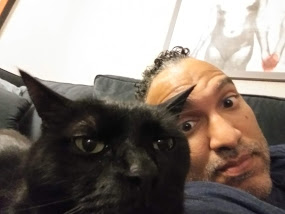

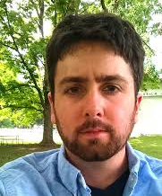

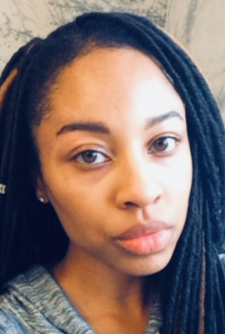

# Instructor Information

Name: Omar Lizardo  
Position: Professor, UCLA Sociology  
Email: olizardo@g.ucla.edu

Name: Isaac Jilbert  
Position: Teaching Assistant, UCLA Sociology  
Sections: 1C, 1E, and 1F  
Email: ijilber1@ucla.edu

Name: Carmella N. Stoddard  
Position: Teaching Assistant, UCLA Sociology  
Sections: 1A, 1B, and 1D  
Email: cstoddard@ucla.edu

# Course Description

These days, “social networks” are everywhere, [including Hollywood movies starring Jesse Eisenberg](https://www.imdb.com/title/tt1285016/), [self-help bestsellers trying to change your life](https://www.imdb.com/title/tt1285016/), to social media websites trying to get you to click on an ad. But way before networks, networking, and social media networks became buzzwords (e.g., before you were born), they were (and continue to be) a field of rigorous study in the social sciences called **social network analysis**. In fact, networks became central in sociology during the 1960s and 1970s because they were used to take such fuzzy concepts as “social relationships,” “social ties,” and “social structures” from being evocative abstractions that explained everything (and thus nothing) to real topics of empirical research. In that way, the notion of social networks went, in the words of [University of Toronto sociologist Barry Wellman](https://en.wikipedia.org/wiki/Barry_Wellman), from “metaphor to theory and substance.”

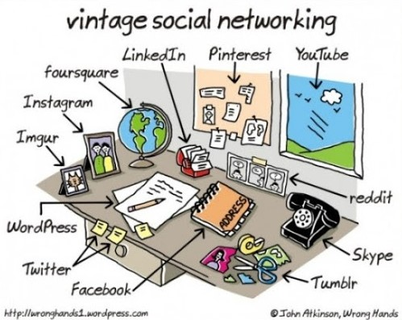

In this course, we will explore this more concrete and “scientific” part of social networks. We will see that the field of study of social networks is distinctive for not only having its own set of theories and concepts (and associated “lingo”) but also for the way in which these concepts are immediately made concrete in mathematical (usually quantitative form). In Social Network Analysis (SNA), there is thus no clear separation of the theory from the analysis part. Another thing is distinctive about SNA concerning other areas of sociology is that it is not thematically restricted. Instead, SNA is comprised of a general set of analytic tools that can be used to study social processes in *any* field of sociology. This course will thus reflect that thematic diversity.

# Thematic Sequence

The first part of the course is designed to introduce you to the entire panoply of concepts and theories that form the core of the field of SNA. This field has a long history, but today it is a massive endeavor recruiting people from all of the social science disciplines. Because the primary tools of SNA are graph theory and matrix Algebra the first part of the course will focus on that, so it will be the most “math heavy” part of the class (although we will encounter math later too). Then beginning around week 4 we will switch over to theories about social networks work, focusing on the case of status attainment. The second half of the class will broaden the scope as we explore how various social phenomena, from collaboration and creativity, to status, hierarchy, negative interactions, the diffusion of innovations (and disease), and “the small world” can be understood from a social network perspective.

[figure not shown]

# Learning Objectives

By the end of the course, you should be able to:

- Understand basic network concepts and theories.
- Use social-scientific terminology to describe patterns of structure and change observed in networks.
- Understand and be capable of using measures based on graph theory and matrix algebra to analyze and describe social networks.
- Understand the way that social network concepts, theory, and measures can be applied to shed light on a wide variety of phenomena across different fields of study in the social sciences and beyond.

# Organization of the Class

# Course Requirements

[figure not shown]

# Expectations and Policies

## Participation

*You are expected to participate in section meetings. This will be part of your grade in the course*. If you are unsure of how best to participate, talk to me or your TA and we will share ideas.

## Email and Course Website

The TAs and I expect you to check your email at least once each weekday and to log in to the course website at least three times a week. As an online course, these are our primary ways of getting in touch with you and ensuring that we are all on the same page. If you are planning to travel, be sure that you have regular access to the internet and a computer while you are away. This is a five-unit general education course. Our experience has been that online students are more successful if they space their work out regularly and predictably each week.

## Homework Assignments

**Please make sure you truly understand a solution, and please: DO NOT COPY SOLUTIONS.** We will figure it out. If we discover that some members of a working group have copied solutions, the entire group will be reported to the Dean of Students on the grounds of Academic Misconduct. Even if we don’t catch you, you won’t really understand what you’ve done, and things will not go well when exams roll around. You’ll only be hurting yourself in the long run.

## Exams

Exams will usually consist of a mixture of multiple choice and fill in the blank questions. Some of the questions will require you to engage in some simple arithmetic computations. Exams – including the final – will only be administered on the scheduled dates. An exception will only be made in the case of a documented illness or family emergency.

# Violence and Discrimination Resources

UCLA prohibits gender discrimination, sexual harassment, domestic and dating violence, sexual assault, and stalking. If you have experienced any of these, there are a variety of campus resources to assist you, including a confidential hotline where you can talk to someone 24/7: (310) 825-0768. Title IX is a federal civil rights law in the United States of America that was passed as part (Title IX) of the Education Amendments of 1972. Therefore international students have access to the same services at the Title IX office as non-international students. Please note that faculty and TAs are responsible employees, which means faculty, TAs, and other UC employees are required under the UC Policy on Sexual Violence and Sexual Harassment to inform the Title IX Coordinator—a non-confidential resource —should they become aware that you or any other student has experienced sexual violence or gender discrimination.

## Campus-Based Confidential Resources:

- You can make an appointment with a CARE advocate to receive confidential support at the CARE Advocacy Office for Sexual and Gender-Based Violence, Murphy A Level, Room 233, CAREadvocate@careprogram.ucla.edu, (310) 206-2465. CARE offers free and confidential services for students, staff and faculty impacted by sexual assault, relationship violence and stalking.
- Counseling and Psychological Services (CAPS) also provides confidential counseling to all students and can be reached 24/7 at (310) 825-0768.
- Confidential legal counseling and assistance is available with [Student Legal Services](https://www.studentlegal.ucla.edu) at A239 Murphy Hall and or phone (310)-825-9894.
- The Office of Ombuds Services provides an informal dispute resolution process for students and postdoctoral employees. You can contact them at (310) 825-7627 Monday through Friday, 8am-5pm.

## Off-Campus Confidential Resources:

- Rape Treatment Center UCLA Medical Center Santa Monica provides off-campus confidential counseling and guidance 24/7. You can contact them at (424) 259-7208.
- BEAM (Black Emotional and Mental Health) is a collective of advocates, yoga teachers, artists, therapists, lawyers, religious leaders, teachers, psychologists and activists committed to the emotional/mental health and healing of Black communities. www.beam.community
- CAT-911 provides alternatives to 911 in sexual violence, domestic violence, mental health crisis, and other crises through transformative justice and conflict resolution. [www.cat-911.org](https://cat-911.org/)
- Sojourn offers support to victims of domestic violence, including shelter, support groups, workshops, hotline calls, children’s empowerment programming, legal services and service referrals. 24/7 hotline: (310) 264-6644
- Peace Over Violence provides emotional support, information, compassion, accompaniment, referral and advocacy services. 24/7 hotline: (213) 626-3393
- Los Angeles LGBT Center offers services by LGBT-domestic violence specialists. Fees on a sliding scale. Call (323) 860-5806 from 9am-5pm or a 24/7 hotline at (888) 799-7233

## Non-Confidential Reporting Resources:

- You can also report sexual violence or sexual harassment directly to the University’s Title IX Office, 2255 Murphy Hall, titleix@conet.ucla.edu, (310) 206-3417.
- Reports to law enforcement can be made to UCPD at (310) 825-1491. If you report through Title IX or UCPD, they may be required to pursue an official investigation.
- **Please note that any appointment you make with a Title IX counselor is NOT confidential.**

[figure not shown]

## Final Grading Scheme

### Assignment Point distribution

| Assignment | Points |
| --- | --- |
| Homework (5, worth 15 pts each) | 75 pts total |
| Section Engagement | 75 pts total |
| Midterm | 75 pts total |
| Final | 75 pts total |
| **Total** | **300** |

### Letter Grade Determination

| Letter Grade | Point % | Point Total |
| --- | --- | --- |
| **A+** | >= 97% | 291+ |
| **A** | 93-96% | 279-290 |
| **A-** | 90-92% | 270-278 |
| **B+** | 87-89% | 261-269 |
| **B** | 83-86% | 249-260 |
| **B-** | 80-82% | 240-248 |
| **C+** | 77-79% | 231-239 |
| **C** | 73-76% | 219-230 |
| **C-** | 70-72% | 210-218 |
| **D** | 60-69% | 180-209 |
| **F** | < 60% | <= 179 |

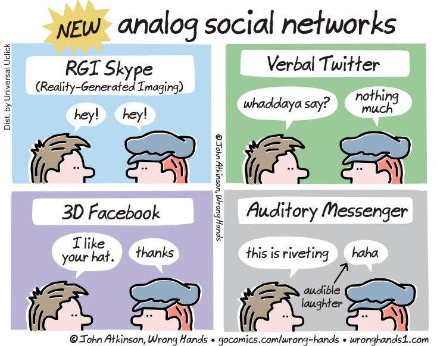

# Communicating with Us

## Rules of engagement

1. I try to be very available to my students. However, like you, I have a life beyond this class. I have a family and friends, other students, and other obligations. The TAs do too!
2. **Before emailing us with a question, please check the syllabus and/or course website to see if it has been answered somewhere else.** Check the emails I send periodically or ask someone from your small group.
3. When you do email or call, please be patient. We might respond immediately, we might not. Give us a day (or a weekend) to get back to you.
4. You don’t need to schedule an appointment for my student hours. My virtual doors are wide open during that time (check with your TA about their particular scheduling policy).
5. However, if you want to meet outside student hours times, please contact me to set up an appointment for a time I am available.
6. Feel free to meet with any of us, regardless of the section you are in. However, if you want to discuss a grade, you must talk with the person who graded your assignment (your TA, unless otherwise noted).

[figure not shown]

## Open Student Hours with Prof. Lizardo

**Tues 9:00-10:00am and Thurs. 3:00-4pm.** Student hours are to discuss general issues related to the class or the course content (e.g., points of clarification, questions about the material, etc.).

Virtual Office Link: https://ucla.zoom.us/my/olizardo  
Appointment Slot Link: https://tinyurl.com/ya35qudy

## Academic Code of Conduct

Students are strongly encouraged to discuss ideas for papers and assignments with other students. You can also show drafts of your papers to other students and receive from them editing assistance. However, all written work (papers, posted questions and comments) must be written by the student submitting the work. Any suspected instance of cheating or plagiarism will be dealt with according to the policies of UCLA’s Honor Code. As an undergraduate at the UCLA, you are bound by the University’s academic code of conduct found [here](https://www.deanofstudents.ucla.edu/Individual-Student-Code).

We expect that everyone by now is familiar with it because not knowing the rules is not an excuse; you can violate the conduct without knowing it. So (re) familiarize yourself with it. Of most relevance to the class, is the part of the code of conduct that deals with “Academic Dishonesty.” This term covers a wide range of behaviors and practices, some of which you may think is not such a big deal at all (e.g., copying and pasting a sentence from a Wikipedia article without citation or attribution). Note, however, that academic dishonesty covers much more than that and includes but is not limited to: “cheating, fabrication or falsification, plagiarism, multiple submissions or facilitating academic misconduct which occurs in academic exercises or submissions.”

# Frequently Asked Questions

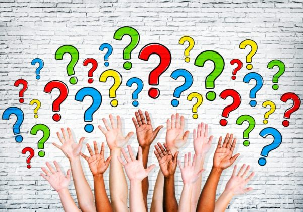

- *I don’t like the time my discussion section meets. Can I join another one?*

> **No**. You are assigned to the discussion section you are assigned by the registrar and each section must remain the size that it is. However, if you do the legwork of finding another student to switch with you and notify both TAs about it, you may do so.
- *Is there a discussion the first week?*

> **No**. There are no discussion section meetings the first week.
- *I can’t make it to the required lecture time or I missed a lecture. Where can I find the recording?*

> **No**. The beauty of network analysis is that we can clarify social science concepts using math. So most of the time, formulas will be there just to show that this can be done. However, there will be a very small amount (two to three) formulas that are very basic and that you should be able to use in the exam to come up with answers to the question. *I will let you know exactly which formulas these are* and where to find them in the lecture slides and the online textbook.
- *There are lots of concepts and terminology. Do I need to know everything definition?*

> **No**. The textbook goes into more detail on the material and provide important background on key concepts. For the most part the lecture slides should be your guide as to what is important. If it is mentioned on both the textbook and the lecture, it will likely be in the exam. If it is mentioned in the textbook but not the lecture, I will not test you on it.
- *When should I turn my homework in?*

> Homeworks are due on the week indicated at your discussion section meeting and should be turned in to your assigned TA.
- *I have multiple final exams on the same day as the one scheduled for this course, can I make a private arrangement to take the final on a different day?*

> **No**. The final is scheduled over a 12 hour window. This should allow you to find a time to take it without conflict. This is also information that is available to you from the get go so you can plan accordingly. Making private arrangements with every individual who has multiple finals scheduled for the same day would be both unworkable and unfair to others. The only reasons to reschedule an exam remain the ones listed above: Documentable emergencies, mental and physical health issues, or deaths in the family.
- *Can we band together on a group chat, concoct a petition and lobby for everyone to get an A, change the date of the exams, demand that homework be abolished and generally use the tough time everyone is having due to Covid to don’t do any of the work required to pass the class and still pass the class?*

> I mean, you could do all of that, but it won’t work. So my answer is **No**, and don’t even think about trying that stuff on me. The course requirements are clearly laid out, so you should be able to anticipate whether you can meet them or not. Everything will take place as written and stipulated here (unless I decide to change out of my own volition). So plan accordingly and don’t count on petition magic to save you.